# Predicting Daily High Temperature Using XGBoost

Los Angeles International Airport (KLAX)

Authors

Alex Lewis

David Moe

Advisor: Dr. Cohen

Published

July 19, 2026

Slides: slides.html

## Introduction

The accurate prediction of daily high temperatures is an important component of modern weather forecasting. It influences decision-making across various market sectors such as energy management, transportation, and public safety. By obtaining reliable temperature forecasts, resources can be efficiently allocated in areas such as electricity demand planning and climate-sensitive operations in aviation and infrastructure. In recent years, advances in data-driven modeling have improved upon traditional numerical weather prediction methods, offering improved accuracy and adaptability for localized forecasting tasks (Wang et al. 2023). Machine learning techniques, in particular ensemble methods, have demonstrated strong performance in capturing nonlinear and interaction relationships within meteorological data (Airlangga 2025). Among these, Extreme Gradient Boosting (XGBoost) has emerged as a powerful and efficient algorithm for predictive modeling in structured datasets (Chen and Guestrin 2016).

Recent research has been exploring the use of various machine learning techniques to enhance weather prediction accuracy, particularly in short-term forecasting applications. Ensemble learning methods such as XGBoost have been shown to outperform traditional statistical models and complement numerical weather prediction systems by effectively capturing nonlinear relationships and correcting systematic biases (Dong et al. 2023). Prior studies have applied XGBoost to tasks such as precipitation forecasting and bias correction of meteorological outputs, demonstrating improved predictive performance across diverse geographic regions (Dong et al. 2023). Additionally, a comparative analysis of machine learning algorithms highlights the robustness and computational efficiency of gradient boosting approaches when applied to structured environmental data (Zhou 2023; Singh and Rawat 2023; Airlangga 2025). Despite these advances, many studies focus on regional or large-scale forecasting problems, leaving opportunities for more localized, site-specific modeling of daily temperature using high-frequency observational data. XGBoost has also been documented in tutorial and use-case contexts for its implementation and interpretability in applied machine learning problems (Wiens et al. 2025).

This study focuses on predicting daily high temperatures at the Los Angeles International Airport (KLAX) station using high-frequency observational data obtained from the National Oceanic and Atmospheric Administration (NOAA) Automated Surface Observing System (ASOS) (Environmental Information (NCEI) 2026). The dataset consists of 5-minute interval weather measurements, providing a detailed view of atmospheric conditions that can be aggregated to support daily forecasting tasks (Khan and Al-Hajj 2025). By leveraging this granular data, this study aims to capture shorter-term variability and improve the accuracy of daily maximum temperature predictions. An XGBoost regression model is developed to model the relationship between meteorological features and daily high temperatures, with an emphasis on evaluating its predictive performance in a localized airport environment. This approach provides a practical framework for applying machine learning techniques to site-specific temperature forecasting using publicly available data.

The primary objective of this study is to develop and evaluate an XGBoost-based model for predicting daily high temperatures at the KLAX airport in Los Angeles, California using the aggregated NOAA ASOS data. The model performance is assessed using a comprehensive set of regression evaluation metrics, including Mean Absolute Error (MAE), Mean Squared Error (MSE), Root Mean Squared Error (RMSE), $R^2$, Mean Absolute Percentage Error (MAPE), and Explained Variance, to provide a thorough assessment of prediction accuracy, error magnitude, and model fit. In addition, the study examines feature importance to better understand the contribution of key meteorological variables to model predictions. By focusing on a single location, KLAX, and leveraging high-frequency data, this research aims to demonstrate the applicability of XGBoost for localized temperature forecasting. The findings contribute to the growing body of work on data-driven weather prediction and highlight the potential of XGBoost as a practical tool for operational forecasting tasks, consistent with prior statistical temperature prediction work in California and broader North America (Dias et al. 2018).

## Methods

The prediction task is to forecast the daily maximum air temperature, $T_{\max}$, at weather station KLAX from surface observations. The relationship between the predictors and $T_{\max}$, is highly interaction‑dependent. For example, the cooling associated with west‑to‑east wind gusts varies by hour of the day and season, so the marginal effect of any one variable is not constant across the others. As a result, the conditional structure cannot be captured by additive linear terms alone. This analysis therefore employs gradient‑boosted regression trees as implemented in XGBoost (Chen and Guestrin 2016), which are well suited to modeling nonlinear, interacting predictors in tabular meteorological data.

We construct an additive ensemble of $K$ regression trees $f_k$ drawn from the space $\mathcal{F}$,

$$\hat{y}_i = \sum_{k=1}^{K} f_k(\mathbf{x}_i), \qquad f_k \in \mathcal{F}, \tag{1}$$

where $x_i$ denotes the predictor vector for observation $i$ and $\hat{y}_i$ is the corresponding model prediction. The ensemble is fitted by stagewise minimization of a regularized objective that penalizes both the number of leaves and the magnitude of leaf prediction scores in each tree:

$$\mathcal{L} = \sum_{i} l(\hat{y}_i, y_i) + \sum_{k=1}^{K} \left[ \gamma T_k + \tfrac{1}{2}\lambda \lVert w_k \rVert^2 \right]. \tag{2}$$
where $l(\hat{y}_i, y_i)$ is the loss function (squared error in this study), $T_k$ is the number of leaves in tree $k$, and $w_k$ is the vector of leaf scores for that tree.

This method suits our data for three reasons. First, it does not require the predictors to share common units or scales; variables such as wind speed and air temperature can interact naturally within the trees. Second, XGBoost includes explicit handling of missing values, so gaps in the observational record, i.e., sensor failures or unmeasured gusts, can be accommodated without discarding entire days or imputing values. Third, the fitted model can report which conditions contributed most to its predictions through feature importance and related diagnostics, allowing us to verify that the inferred drivers of high temperatures align with established meteorological cause‑and‑effect relationships.

## Analysis and Results

### Data Exploration and Visualization

#### Data Sources and Collection Process

The temperature data used in this study were obtained from the National Oceanic and Atmospheric Administration (NOAA) National Centers for Environmental Information (NCEI) Automated Surface Observing System (ASOS) network (Environmental Information (NCEI) 2026). ASOS is the primary automated surface observing network in the United States and provides continuous meteorological observations at airport-based stations, including Los Angeles International Airport (KLAX), with archived one-minute and five-minute products available through NCEI. The dataset used in this study consists of 5-minute interval observations for KLAX from January 1, 2000 through June 7, 2026 and includes variables as described in the following table:

| Variable Name | Variable | Description |
| --- | --- | --- |
| Timestamp | `datetime_utc` | Date and time of the observation in Coordinated Universal Time (UTC). |
| Wind Direction | `wind_dir` | Direction the wind is coming from, usually reported in degrees. |
| Wind Speed | `wind_speed_kt` | Sustained wind speed in knots. |
| Wind Gust | `wind_gust_kt` | Maximum gust wind speed in knots. |
| Visibility | `visibility_sm` | Horizontal visibility in statute miles. 10sm Max. |
| Weather | `weather` | Reported weather phenomena, such as rain, fog, or thunderstorms. |
| Sky Condition | `sky_condition` | Description of cloud cover or sky state, such as clear, scattered, broken, or overcast. |
| Temperature | `temp_c` | Air temperature in degrees Celsius. |
| Dew Point | `dewpoint_c` | Dew point temperature in degrees Celsius. |
| Relative Humidity | `rh_pct` | Relative humidity expressed as a percentage. |
| Altimeter Pressure | `altimeter_inhg` | Altimeter setting or atmospheric pressure in inches of mercury. |

```r
# =========================================================
# Load Packages
# =========================================================

library(arrow)
library(dplyr)
library(lubridate)
library(ggplot2)
library(knitr)
library(patchwork)
library(scales)
library(tibble)
library(tidyr)
library(xgboost)

# =========================================================
# Setup Paths
# =========================================================

parquet_path <- "KLAX_5min_complete.parquet"
output_dir <- "output"
reference_time <- ymd_hms("2026-06-07 23:25:00", tz = "UTC")

if (!dir.exists(output_dir)) {
  dir.create(output_dir)
}

# =========================================================
# Import Data
# =========================================================

ts_col <- "datetime_utc"
temp_col <- "temp_c"

df_raw <- read_parquet(parquet_path)

df_all <- df_raw %>%
  mutate(
    timestamp      = as_datetime(.data[[ts_col]], tz = "UTC"),
    temp           = as.numeric(.data[[temp_col]]),
    dewpoint_c     = as.numeric(dewpoint_c),
    rh_pct         = as.numeric(rh_pct),
    wind_dir_deg   = as.numeric(wind_dir),
    wind_speed_kt  = as.numeric(wind_speed_kt),
    wind_gust_kt   = as.numeric(wind_gust_kt),
    visibility_sm  = as.numeric(visibility_sm),
    altimeter_inhg = as.numeric(altimeter_inhg)
  ) %>%
  mutate(
    visibility_sm = ifelse(is.finite(visibility_sm), visibility_sm, NA_real_)
  ) %>%
  mutate(
    wind_gust_kt = ifelse(!is.na(wind_gust_kt) & wind_gust_kt > 100, NA_real_, wind_gust_kt),
    visibility_sm = ifelse(!is.na(visibility_sm) & visibility_sm > 10, NA_real_, visibility_sm)
  ) %>%
  arrange(timestamp)

# =========================================================
# Derive Variables
# =========================================================

df_all <- df_all %>%
  mutate(
    temp_change_5min = temp - lag(temp),
    abs_temp_change_5min = abs(temp_change_5min),
    timestamp_lag_3h = lag(timestamp, 36),
    temp_lag_3h = lag(temp, 36),
    temp_change_3h = temp - temp_lag_3h,
    timestamp_future_3h = lead(timestamp, 36),
    temp_future_3h = lead(temp, 36),
    temp_change_next_3h = temp_future_3h - temp,
    wind_group = case_when(
      wind_dir_deg >= 210 & wind_dir_deg <= 330 ~ "West winds",
      wind_dir_deg >= 30 & wind_dir_deg <= 150 ~ "East winds",
      TRUE ~ NA_character_
    ),
    gust_wind_group = case_when(
      wind_dir_deg >= 210 & wind_dir_deg <= 330 ~ "Westerly gusts (west to east)",
      wind_dir_deg >= 30 & wind_dir_deg <= 150 ~ "Easterly gusts (east to west)",
      TRUE ~ NA_character_
    )
  )

# =========================================================
# Build Subsets (Full Record)
# =========================================================

df_full <- df_all %>%
  filter(!is.na(temp))

df_5min_change_all <- df_all %>%
  filter(!is.na(temp_change_5min))

df_3h_change_all <- df_all %>%
  filter(
    !is.na(temp_change_3h),
    as.numeric(timestamp - timestamp_lag_3h, units = "mins") == 180
  )

df_3h_gust_change <- df_all %>%
  filter(
    !is.na(wind_gust_kt),
    wind_gust_kt < 100,
    !is.na(temp_change_next_3h),
    !is.na(gust_wind_group),
    as.numeric(timestamp_future_3h - timestamp, units = "mins") == 180,
    abs(temp_change_next_3h) <= 10
  )

zero_changes <- df_5min_change_all %>%
  filter(temp_change_5min == 0)

nonzero_changes <- df_5min_change_all %>%
  filter(temp_change_5min != 0)

prop_zero <- nrow(zero_changes) / nrow(df_5min_change_all)

# =========================================================
# Build Daily High Data
# =========================================================

daily_high <- df_full %>%
  mutate(date = as_date(timestamp)) %>%
  group_by(date) %>%
  summarise(
    daily_high_temp = max(temp, na.rm = TRUE),
    .groups = "drop"
  ) %>%
  filter(!is.na(daily_high_temp))

daily_high_months <- daily_high %>%
  mutate(month = month(date, label = TRUE, abbr = TRUE))

daily_high_doy <- daily_high %>%
  mutate(
    year = year(date),
    doy = yday(date)
  ) %>%
  filter(doy <= 365)

doy_stats <- daily_high_doy %>%
  group_by(doy) %>%
  summarise(
    mean_high = mean(daily_high_temp, na.rm = TRUE),
    q1_high = quantile(daily_high_temp, 0.25, na.rm = TRUE),
    q3_high = quantile(daily_high_temp, 0.75, na.rm = TRUE),
    min_high = min(daily_high_temp, na.rm = TRUE),
    max_high = max(daily_high_temp, na.rm = TRUE),
    .groups = "drop"
  )

day_of_year_month_starts <- tibble(
  doy = c(1, 32, 60, 91, 121, 152, 182, 213, 244, 274, 305, 335),
  month = c("Jan", "Feb", "Mar", "Apr", "May", "Jun",
            "Jul", "Aug", "Sep", "Oct", "Nov", "Dec")
)

# =========================================================
# Build Diurnal Data
# =========================================================

diurnal_avg <- df_full %>%
  mutate(hour = hour(timestamp)) %>%
  group_by(hour) %>%
  summarise(
    avg_temp = mean(temp, na.rm = TRUE),
    .groups = "drop"
  )

# =========================================================
# Build Event Window Data
# =========================================================

start_time <- ymd_hms("2025-07-22 00:00:00", tz = "UTC")
end_time <- ymd_hms("2025-07-23 12:00:00", tz = "UTC")

event_data <- df_all %>%
  filter(timestamp >= start_time, timestamp <= end_time)

# =========================================================
# Helper Functions
# =========================================================

make_descriptive_row <- function(data, variable, label) {
  x <- data[[variable]]

  tibble(
    Variable = label,
    N = sum(!is.na(x)),
    Mean = mean(x, na.rm = TRUE),
    SD = sd(x, na.rm = TRUE),
    Q1 = quantile(x, 0.25, na.rm = TRUE),
    Median = median(x, na.rm = TRUE),
    Q3 = quantile(x, 0.75, na.rm = TRUE),
    Min = min(x, na.rm = TRUE),
    Max = max(x, na.rm = TRUE)
  )
}

save_plot <- function(plot_object, file_name, width = 7, height = 5, dpi = 300) {
  ggsave(
    filename = file.path(output_dir, file_name),
    plot = plot_object,
    width = width,
    height = height,
    dpi = dpi
  )
}

# =========================================================
# Helper Plot Theme
# =========================================================

theme_capstone <- theme_minimal() +
  theme(
    plot.title = element_text(face = "bold"),
    plot.subtitle = element_text(color = "grey40"),
    plot.caption = element_text(color = "grey50", size = 8),
    legend.position = "bottom"
  )
```

```r
# =========================================================
# Observation Tables
# =========================================================

processing_stats <- tibble(
  Statistic = c(
    "Total 5-minute observations",
    "Total non-missing temperature values",
    "Days with daily high temperature values"
  ),
  Value = c(
    nrow(df_all),
    sum(!is.na(df_all$temp)),
    nrow(daily_high)
  )
)

knitr::kable(
  processing_stats,
  caption = "Observation counts for KLAX, 2000-2026",
  digits = 2
)
```

Table 1: Observation counts for KLAX, 2000-2026

| Statistic | Value |
| --- | --- |
| Total 5-minute observations | 2523612 |
| Total non-missing temperature values | 2520906 |
| Days with daily high temperature values | 9337 |

For this analysis, we begin by finding the number of observations within the dataset.  
Table 1 shows the total number of observations and the total number of non-missing values. There are 9,337 values for daily high temperatures. This provides a large amount of data for this analysis and the modeling of daily high temperatures later in this study.

#### Descriptive Statistics

```r
# =========================================================
# Descriptive Statistics Table
# =========================================================

continuous_summary <- bind_rows(
  make_descriptive_row(df_full, "wind_speed_kt", "Wind speed (kt)"),
  make_descriptive_row(df_full, "wind_gust_kt", "Wind gust (kt)"),
  make_descriptive_row(df_full, "visibility_sm", "Visibility (statute mi)"),
  make_descriptive_row(df_full, "temp", "Air temperature (°C)"),
  make_descriptive_row(df_full, "dewpoint_c", "Dewpoint temperature (°C)"),
  make_descriptive_row(df_full, "rh_pct", "Relative humidity (%)"),
  make_descriptive_row(df_full, "altimeter_inhg", "Altimeter (inHg)")
)

knitr::kable(
  continuous_summary,
  caption = "Descriptive statistics for KLAX 5-minute variables, 2000–2026.",
  digits = 2
)
```

Table 2: Descriptive statistics for KLAX 5-minute variables, 2000–2026.

| Variable | N | Mean | SD | Q1 | Median | Q3 | Min | Max |
| --- | --- | --- | --- | --- | --- | --- | --- | --- |
| Wind speed (kt) | 2515636 | 6.27 | 4.25 | 3.00 | 6.00 | 9.00 | 0.00 | 39.00 |
| Wind gust (kt) | 73146 | 20.97 | 5.04 | 17.00 | 20.00 | 23.00 | 13.00 | 77.00 |
| Visibility (statute mi) | 2517636 | 8.60 | 2.40 | 8.00 | 10.00 | 10.00 | 0.00 | 10.00 |
| Air temperature (°C) | 2520906 | 17.15 | 4.03 | 14.00 | 17.00 | 20.00 | -12.00 | 41.00 |
| Dewpoint temperature (°C) | 2520080 | 10.96 | 5.82 | 8.90 | 12.20 | 15.00 | -24.00 | 80.00 |
| Relative humidity (%) | 2514747 | 69.98 | 19.03 | 62.00 | 74.00 | 83.00 | 3.00 | 100.00 |
| Altimeter (inHg) | 2520624 | 29.98 | 0.11 | 29.91 | 29.97 | 30.05 | 9.85 | 30.49 |

The descriptive statistics of the selected continuous variables in Table 2 indicate that most predictors are well-behaved but do not strictly follow a normal Gaussian distribution, with moderate skewness, truncation, and differing scales across variables. This supports the use of a flexible, nonparametric model such as XGBoost. Wind speed and gusts show positive, right-skew with the mean being greater than the median and larger max values further indicating the long right tail. Wind gusts also show significantly less observations compared to the other variables. On the other hand, relative humidity exhibits a negative, left-skew with occasional very dry conditions.

Furthermore, visibility is heavily concentrated at its upper bound of 10 statute miles. Altimeter readings are tightly clustered around the mean with minimal variance. In combination, these features form a predictor set with mixed distributional shapes, bounded ranges, and differing levels of measurement frequency, such as the smaller number of observations for gusts, making tree-based gradient boosting particularly suitable because it does not rely on linearity or normality assumptions and handles non-linear interactions and threshold effects naturally.

Variables such as wind speed, dewpoint temperature, and relative humidity carry substantial variability which can provide strong predictive signals. XGBoost can also accommodate the reduced sample size for wind gusts. Taken together, these descriptive statistics justify the choice of XGBoost as the selected model for this dataset, as it can exploit non-linear relationships and interaction effects while remaining robust to skewed, bounded, and partially observed variables.

```r
# =========================================================
# Temperatures by Wind Groups Table
# =========================================================

temp_by_wind_summary <- df_all %>%
  filter(!is.na(wind_group), !is.na(temp)) %>%
  group_by(wind_group) %>%
  summarise(
    N = sum(!is.na(temp)),
    Mean = mean(temp, na.rm = TRUE),
    SD = sd(temp, na.rm = TRUE),
    Q1 = quantile(temp, 0.25, na.rm = TRUE),
    Median = median(temp, na.rm = TRUE),
    Q3 = quantile(temp, 0.75, na.rm = TRUE),
    Min = min(temp, na.rm = TRUE),
    Max = max(temp, na.rm = TRUE),
    .groups = "drop"
  )

names(temp_by_wind_summary)[1] <- "Wind Group"

knitr::kable(
  temp_by_wind_summary,
  caption = "Descriptive statistics for air temperature grouped by east-wind and west-wind observations at KLAX, 2000-2026.",
  digits = 2
)
```

Table 3: Descriptive statistics for air temperature grouped by east-wind and west-wind observations at KLAX, 2000-2026.

| Wind Group | N | Mean | SD | Q1 | Median | Q3 | Min | Max |
| --- | --- | --- | --- | --- | --- | --- | --- | --- |
| East winds | 490241 | 14.96 | 4.05 | 12 | 14.4 | 17.2 | -6 | 41 |
| West winds | 1381246 | 18.30 | 3.62 | 16 | 18.0 | 21.0 | 4 | 40 |

Table 3 provides a summary of air temperatures based on whether the wind is blowing from east to west or west to east. First, west winds occur more frequently with roughly three times as many observations as east winds. West winds also exhibit higher mean and median temperatures when compared to east winds. East winds show a much lower minimum temperature, indicating that the east winds are more likely to occur during cooler seasonal periods. While this appears counterintuitive to the typical understanding that cool marine west winds provide cooler temperatures, this could be indicative of underlying seasonal weather patterns where east winds might prevail during cooler seasons like the winter months. Furthermore, while the average temperatures may be higher while west winds prevail, wind gusts from the west can still provide a stronger and more frequent cooling effect when compared to east gusts. This is seen later in this study in Figure 8 and supports the idea of an underlying seasonal component for the difference between average temperatures between east and west wind groups.

```r
# =========================================================
# Temperature Summary Statistics
# =========================================================

abs_q <- quantile(
  df_5min_change_all$abs_temp_change_5min,
  probs = c(0.5, 0.75, 0.9, 0.95, 0.99, 1.0),
  na.rm = TRUE
)

abnormal_threshold <- abs_q["99%"]

df_5min_change_all <- df_5min_change_all %>%
  mutate(abnormal_change = abs_temp_change_5min > abnormal_threshold)

summary_stats <- tibble(
  Statistic = c(
    "Total observations",
    "Mean absolute 5-minute change (°C)",
    "Median absolute 5-minute change (°C)",
    "75th percentile (°C)",
    "90th percentile (°C)",
    "95th percentile (°C)",
    "99th percentile (°C) [abnormal threshold]",
    "Maximum absolute 5-minute change (°C)",
    "Number of abnormal changes",
    "Percentage of abnormal changes (%)"
  ),
  Value_raw = c(
    nrow(df_5min_change_all),
    mean(df_5min_change_all$abs_temp_change_5min, na.rm = TRUE),
    median(df_5min_change_all$abs_temp_change_5min, na.rm = TRUE),
    abs_q["75%"],
    abs_q["90%"],
    abs_q["95%"],
    abs_q["99%"],
    max(df_5min_change_all$abs_temp_change_5min, na.rm = TRUE),
    sum(df_5min_change_all$abnormal_change, na.rm = TRUE),
    100 * mean(df_5min_change_all$abnormal_change, na.rm = TRUE)
  )
) %>%
  mutate(
    Value = case_when(
      Statistic %in% c("Total observations", "Number of abnormal changes") ~ comma(Value_raw, accuracy = 1),
      Statistic == "Percentage of abnormal changes (%)" ~ number(Value_raw, accuracy = 0.01),
      TRUE ~ number(Value_raw, accuracy = 0.01)
    )
  )


knitr::kable(
  summary_stats %>% select(Statistic, Value),
  caption = "Summary statistics for 5-minute temperature changes at KLAX, 2000-2026."
)
```

Table 4: Summary statistics for 5-minute temperature changes at KLAX, 2000-2026.

| Statistic | Value |
| --- | --- |
| Total observations | 2,520,205 |
| Mean absolute 5-minute change (°C) | 0.19 |
| Median absolute 5-minute change (°C) | 0.00 |
| 75th percentile (°C) | 0.30 |
| 90th percentile (°C) | 0.90 |
| 95th percentile (°C) | 1.00 |
| 99th percentile (°C) [abnormal threshold] | 1.10 |
| Maximum absolute 5-minute change (°C) | 27.00 |
| Number of abnormal changes | 24,632 |
| Percentage of abnormal changes (%) | 0.98 |

The 75th percentile of 0.30 °C can be seen as an upper range for typical 5-minute changes in temperature. Furthermore, the 90th percentile of 0.90 °C and 95th percentile of 1.00 °C indicate that only a small portion of 5‑minute observations experience changes upwards of 1.00 °C. To help identify potential outliers, the 99th percentile of 1.10 °C is used as the threshold for abnormal changes. Given this threshold, a total of 24,632 5-minute temperature changes, or 0.98% of total observations, were greater than 1.10 °C, with the maximum change reading 27.00 °C. The relatively small number of extreme outliers are likely from sensor failures or extreme weather events such as a cold front from a high pressure system.

#### Visualizations and Insights

Exploratory analysis through visualizations of the KLAX dataset provides further insights into the distribution of the data and seasonal patterns present within the data. To begin, we examine the time series of daily high temperatures 2000 to 2026 in Figure 1. This figure shows yearly seasonality, with warmer peaks in late summer and cooler conditions in winter. There does not appear to be any long term drift with a longer term average around 22 °C.

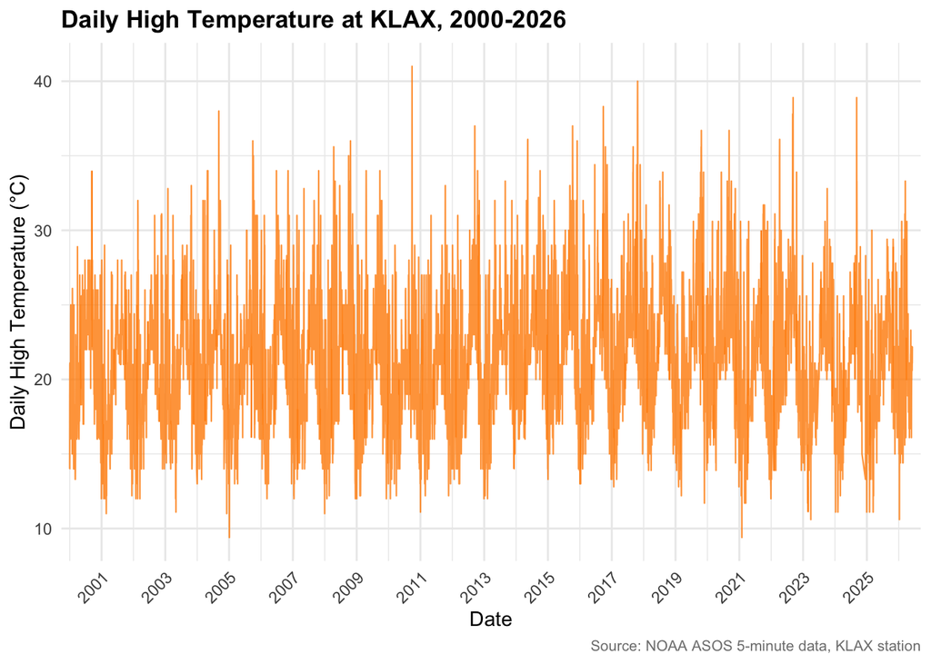

Figure 1: Daily high temperature at KLAX, 2000-2026.

```r
# =========================================================
# Daily High Time Series Plot
# =========================================================

p_daily_high <- ggplot(daily_high, aes(x = date, y = daily_high_temp)) +
  geom_line(color = "darkorange", alpha = 0.8, linewidth = 0.4) +
  labs(
    title = "Daily High Temperature at KLAX, 2000-2026",
    x = "Date",
    y = "Daily High Temperature (°C)",
    caption = "Source: NOAA ASOS 5-minute data, KLAX station"
  ) +
  scale_x_date(
    date_breaks = "2 years",
    date_labels = "%Y",
    expand = c(0.01, 0.01)
  ) +
  theme_capstone +
  theme(
    axis.text.x = element_text(angle = 45, hjust = 1)
  )

p_daily_high
save_plot(p_daily_high, "fig_daily_high_temp_ts.png")
```

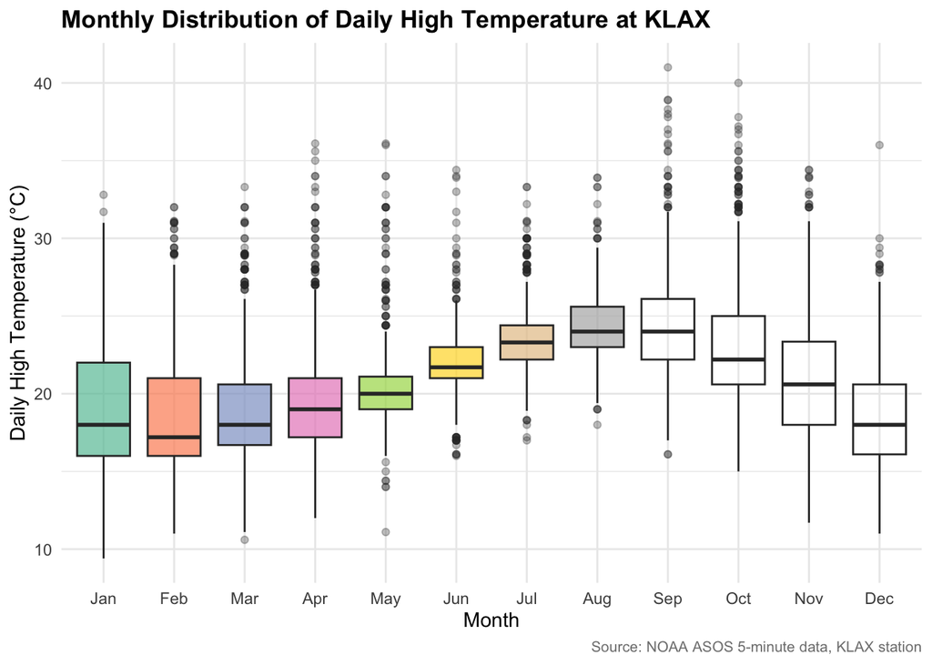

Figure 2: Monthly distribution of daily high temperature at KLAX, 2000-2026.

```r
# =========================================================
# Monthly Distribution Boxplot
# =========================================================

p_boxplot <- ggplot(daily_high_months, aes(x = month, y = daily_high_temp, fill = month)) +
  geom_boxplot(alpha = 0.7, outlier.alpha = 0.3) +
  labs(
    title = "Monthly Distribution of Daily High Temperature at KLAX",
    x = "Month",
    y = "Daily High Temperature (°C)",
    caption = "Source: NOAA ASOS 5-minute data, KLAX station"
  ) +
  scale_fill_brewer(palette = "Set2") +
  theme_minimal() +
  theme(
    plot.title = element_text(face = "bold"),
    plot.subtitle = element_text(color = "grey40"),
    plot.caption = element_text(color = "grey50", size = 8,),
    legend.position = "none"
  )

p_boxplot
save_plot(p_boxplot, "fig_boxplot.png")
```

Figure 3 shows the same distributional and seasonal patterns at the daily resolution, with mean daily highs climbing steadily from February into late summer, peaking in early September, and then declining through autumn into December. Much like Figure 2, the shaded band (interquartile range) and dashed lines (minimum and maximum) highlight a wider spread between the daily minimum and maximum during the cooler winter season. This pattern indicates that although median high temperatures are greater in late summer, individual winter days exhibit larger variability. Individual days in warmer months, however, still exhibit more frequent high temperature extremes than days in the colder months.

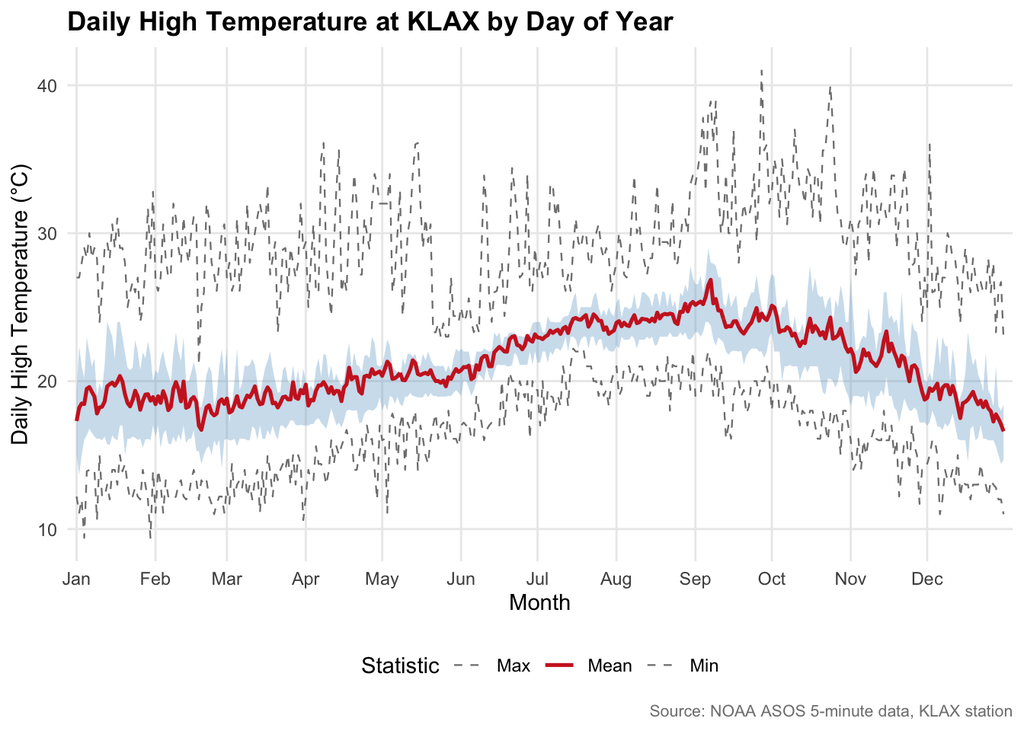

Figure 3: Daily high temperature at KLAX by day of year, showing mean, minimum, maximum, and interquartile range values.

```r
# =========================================================
# Daily High Ranges
# =========================================================

p_daily_high_ranges <- ggplot(doy_stats, aes(x = doy)) +
  geom_ribbon(
    aes(ymin = q1_high, ymax = q3_high),
    fill = "skyblue3",
    alpha = 0.35
  ) +
  geom_line(
    aes(y = min_high, color = "Min"),
    linewidth = 0.4,
    linetype = "dashed"
  ) +
  geom_line(
    aes(y = max_high, color = "Max"),
    linewidth = 0.4,
    linetype = "dashed"
  ) +
  geom_line(
    aes(y = mean_high, color = "Mean"),
    linewidth = 0.9
  ) +
  scale_color_manual(
    name = "Statistic",
    values = c("Min" = "gray50", "Max" = "gray50", "Mean" = "firebrick3")
  ) +
  scale_x_continuous(
    breaks = day_of_year_month_starts$doy,
    labels = day_of_year_month_starts$month,
    expand = c(0.01, 0.01)
  ) +
  labs(
    title = "Daily High Temperature at KLAX by Day of Year",
    x = "Month",
    y = "Daily High Temperature (°C)",
    caption = "Source: NOAA ASOS 5-minute data, KLAX station"
  ) +
  theme_capstone +
  theme(panel.grid.minor = element_blank())

p_daily_high_ranges
save_plot(p_daily_high_ranges, "fig_daily_high_ranges.png")
```

Further visually inspecting the distribution of daily high temperatures in Figure 4, the distribution appears to be normally distributed and concentrated within a moderate range, with most days falling between approximately 16 °C and 24 °C and relatively few very cool or very hot days. There appears to be a mild positive, right-skew with a slightly longer tail due to higher maximum daily high temperatures.

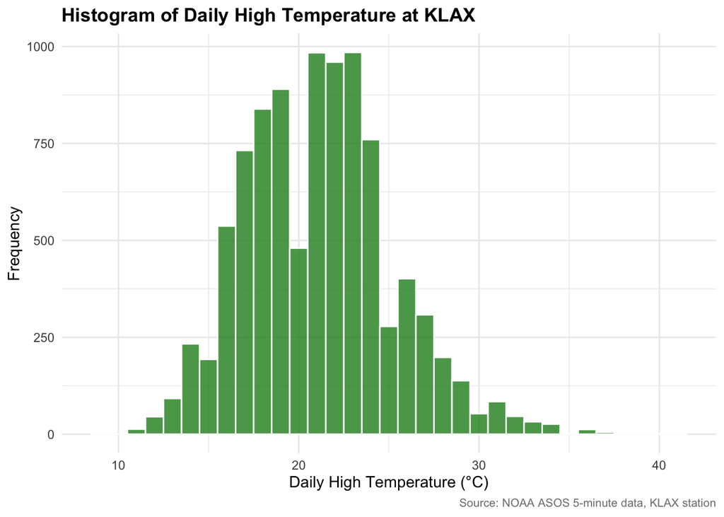

Figure 4: Histogram of daily high temperatures at KLAX, 2000-2026.

```r
# =========================================================
# Daily High Histogram
# =========================================================

p_hist_daily <- ggplot(daily_high, aes(x = daily_high_temp)) +
  geom_histogram(binwidth = 1, fill = "forestgreen", color = "white", alpha = 0.8) +
  labs(
    title = "Histogram of Daily High Temperature at KLAX",
    x = "Daily High Temperature (°C)",
    y = "Frequency",
    caption = "Source: NOAA ASOS 5-minute data, KLAX station"
  ) +
  theme_capstone

p_hist_daily
save_plot(p_hist_daily, "fig_hist_daily_high_temps.png")
```

At the 5-minute resolution, the 5-minute temperature changes exhibit strong persistence with a majority of changes, or 70.1%, remaining steady at 0 °C, supporting the previous findings in Table 4. The histogram of all 5-minute temperature changes in Figure 5 shows an overwhelming concentration at 0 °C. This disproportionate amount of 0 °C obscures the remaining temperature changes.

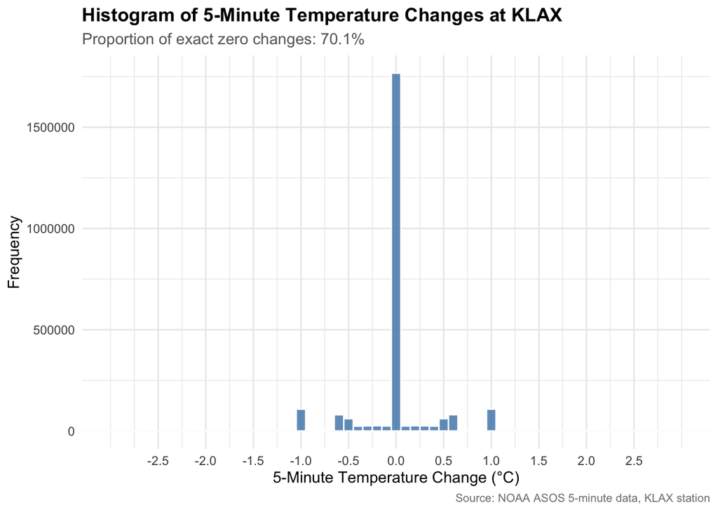

Figure 5: Histogram of all 5-minute temperature changes at KLAX, 2000-2026.

```r
# =========================================================
# 5-Minute Temp Change All Plot
# =========================================================

p_hist_change <- ggplot(df_5min_change_all, aes(x = temp_change_5min)) +
  geom_histogram(
    binwidth = 0.1,
    fill = "steelblue",
    color = "white",
    alpha = 0.8
  ) +
  scale_x_continuous(breaks = seq(-2.5, 2.5, by = 0.5)) +
  coord_cartesian(xlim = c(-3, 3)) +
  labs(
    title = "Histogram of 5-Minute Temperature Changes at KLAX",
    subtitle = sprintf("Proportion of exact zero changes: %.1f%%", 100 * prop_zero),
    x = "5-Minute Temperature Change (°C)",
    y = "Frequency",
    caption = "Source: NOAA ASOS 5-minute data, KLAX station"
  ) +
  theme_capstone

p_hist_change
save_plot(p_hist_change, "fig_5min_temp_change_hist.png")
```

To address this obfuscation, the following non-zero histogram in Figure 6 provides a better look at the remaining 5-minute temperature distribution. This figure confirms that even when changes occur, most changes are small in magnitude and continue to cluster tightly around zero.

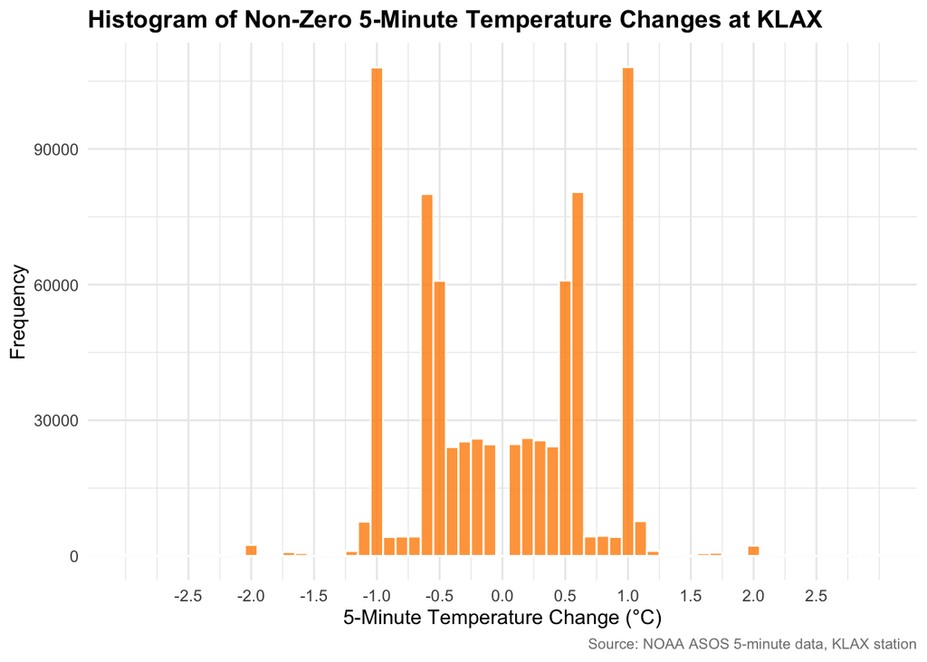

Figure 6: Histogram of non-zero 5-minute temperature changes at KLAX, 2000-2026.

```r
# =========================================================
# 5-Minute Temp Change Excluding Zeros Plot
# =========================================================

p_non_zero_hist <- ggplot(nonzero_changes, aes(x = temp_change_5min)) +
  geom_histogram(
    binwidth = 0.1,
    fill = "darkorange",
    color = "white",
    alpha = 0.8
  ) +
  scale_x_continuous(breaks = seq(-2.5, 2.5, by = 0.5)) +
  coord_cartesian(xlim = c(-3, 3)) +
  labs(
    title = "Histogram of Non-Zero 5-Minute Temperature Changes at KLAX",
    x = "5-Minute Temperature Change (°C)",
    y = "Frequency",
    caption = "Source: NOAA ASOS 5-minute data, KLAX station"
  ) +
  theme_capstone

p_non_zero_hist
save_plot(p_non_zero_hist, "fig_5min_nonzero_change_hist.png")
```

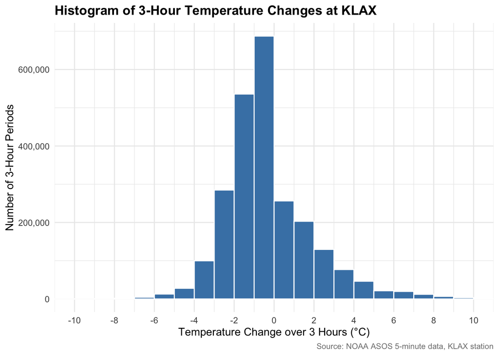

Figure 7: Distribution of 3-hour temperature changes from KLAX 5-minute observations, 2000-2026.

```r
# =========================================================
# 3-hour Temp Changes Histogram
# =========================================================

p_3h_temp_change <- ggplot(df_3h_change_all, aes(x = temp_change_3h)) +
  geom_histogram(binwidth = 1, boundary = 0, fill = "steelblue", colour = "white") +
  scale_x_continuous(breaks = seq(-10, 10, by = 2)) +
  coord_cartesian(xlim = c(-10, 10)) +
  scale_y_continuous(labels = scales::comma) +
  labs(
    title = "Histogram of 3-Hour Temperature Changes at KLAX",
    x = "Temperature Change over 3 Hours (°C)",
    y = "Number of 3-Hour Periods",
    caption = "Source: NOAA ASOS 5-minute data, KLAX station"
  ) +
  theme_capstone

p_3h_temp_change
save_plot(p_3h_temp_change, "fig_3h_temp_change.png")
```

Figure 8 compares the 3-hour temperature changes after gusts from both east and west, or onshore versus offshore gusts. As previously discussed, average temperatures tend to be higher during periods when west winds are present. However, this does not imply that west winds and gusts do not provide a cooling effect. As seen in Figure 8, westerly gusts from offshore provide both a more frequent and stronger cooling effect than easterly gusts from onshore.

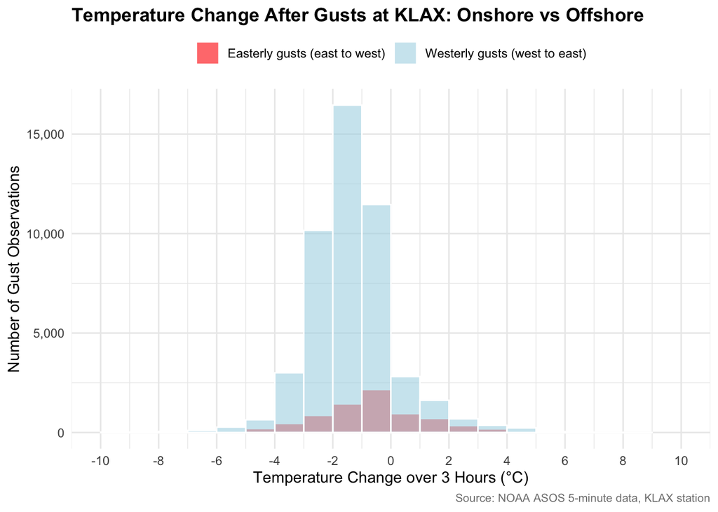

Figure 8: Distribution of 3-hour temperature change following gust observations at KLAX, grouped by easterly and westerly wind regimes, 2000-2026.

```r
# =========================================================
# 3-hour Wind Gust Temp Changes Histogram
# =========================================================

p_3h_wind_change <- ggplot(df_3h_gust_change, aes(x = temp_change_next_3h, fill = gust_wind_group)) +
  geom_histogram(
    binwidth = 1,
    boundary = 0,
    position = "identity",
    alpha = 0.6,
    colour = "white"
  ) +
  scale_x_continuous(breaks = seq(-10, 10, by = 2)) +
  coord_cartesian(xlim = c(-10, 10)) +
  scale_y_continuous(labels = scales::comma) +
  scale_fill_manual(
    values = c(
      "Westerly gusts (west to east)" = "lightblue",
      "Easterly gusts (east to west)" = "red"
    )
  ) +
  labs(
    title = "Temperature Change After Gusts at KLAX: Onshore vs Offshore",
    x = "Temperature Change over 3 Hours (°C)",
    y = "Number of Gust Observations",
    caption = "Source: NOAA ASOS 5-minute data, KLAX station",
    fill = NULL
  ) +
  theme_capstone +
  theme(legend.position = "top")

p_3h_wind_change
save_plot(p_3h_wind_change, "fig_3h_wind_change.png")
```

Next, a diurnal cycle, or how a variable such as air temperature changes over a 24‑hour day, typically warming during the daytime and cooling at night, is visualized to show how the hour of day relates to the timing of daily high temperatures. The diurnal cycle plot in Figure 9 provides an additional view of the short‑term structure by averaging temperature at each hour of the day. This figure shows the coolest temperatures during the early morning hours, a strong, steady increase through the morning, and a peak in the early afternoon around 12 p.m., followed by gradual evening cooling. This behavior is consistent with expected solar‑heating dynamics on a daily basis. The smooth and interpretable daily pattern suggests that time‑based predictors such as hour of day, day of year, or season are likely to be useful in downstream modeling.

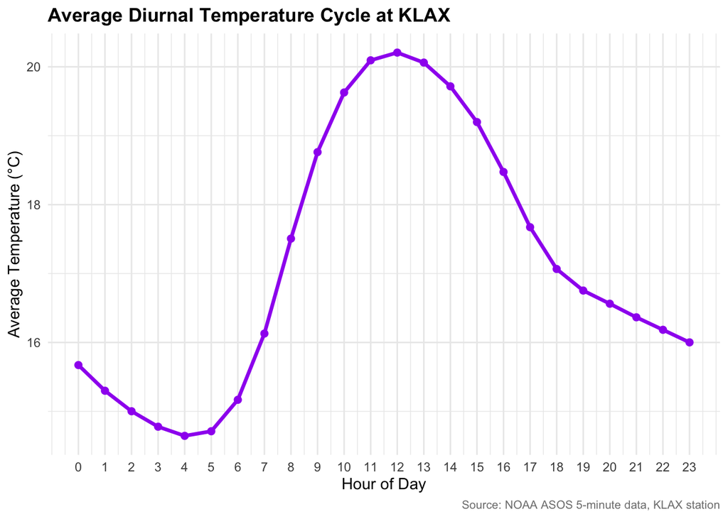

Figure 9: Average diurnal temperature cycle at KLAX, 2000-2026.

```r
# =========================================================
# Diurnal Cycle Plot
# =========================================================

p_diurnal <- ggplot(diurnal_avg, aes(x = hour, y = avg_temp)) +
  geom_line(color = "purple", linewidth = 1.2) +
  geom_point(color = "purple", size = 2) +
  scale_x_continuous(breaks = 0:23) +
  labs(
    title = "Average Diurnal Temperature Cycle at KLAX",
    x = "Hour of Day",
    y = "Average Temperature (°C)",
    caption = "Source: NOAA ASOS 5-minute data, KLAX station"
  ) +
  theme_capstone

p_diurnal
save_plot(p_diurnal, "fig_diurnal_cycle.png")
```

Finally, a more detailed example of the short‑term multi‑variable structure is shown in Figure 10, which presents a 36‑hour sequence of 5‑minute KLAX observations from July 22–23, 2025. Over this interval, temperature increases during the daytime, cools overnight, and rises again the following day. The dewpoint remains comparatively stable, indicating that most of the variation is driven by solar heating and cooling cycles as previously identified in Figure 9, rather than large shifts in moisture content. Relative humidity varies inversely with temperature, and wind speed increases during the afternoon with several gusts exceeding 20 kt. Visibility remains near 10 statute miles for most of the period, and altimeter pressure changes are gradual with minimal short‑term variation. Together, these patterns show that the ASOS dataset captures coherent meteorological relationships across variables and supports the use of these predictors in feature engineering for the XGBoost model.

```r
# =========================================================
# Multivariable Window
# =========================================================

plot_title <- paste0(
  "KLAX 5-minute observations ",
  format(min(event_data$timestamp), "%H:%M %m/%d/%Y"),
  " to ",
  format(max(event_data$timestamp), "%H:%M %m/%d/%Y"),
  " (UTC)"
)

common_x_scale <- scale_x_datetime(
  limits = c(start_time, end_time),
  date_breaks = "6 hours",
  date_labels = "%b %d %H:%M"
)

common_theme <- theme_minimal() +
  theme(
    legend.position = "bottom",
    legend.direction = "horizontal",
    legend.box = "horizontal",
    legend.title = element_blank(),
    plot.title = element_text(face = "bold", size = 11),
    axis.title.x = element_blank()
  )

p1 <- ggplot(event_data, aes(x = timestamp)) +
  geom_line(aes(y = temp, color = "Temperature"), linewidth = 0.5, na.rm = TRUE) +
  geom_line(aes(y = dewpoint_c, color = "Dewpoint"), linewidth = 0.5, na.rm = TRUE) +
  labs(title = "Temperature (°C)", y = NULL) +
  scale_color_manual(values = c("Temperature" = "firebrick", "Dewpoint" = "darkolivegreen4")) +
  common_x_scale +
  common_theme

p2 <- ggplot(event_data, aes(x = timestamp)) +
  geom_line(aes(y = rh_pct, color = "RH"), linewidth = 0.5, na.rm = TRUE) +
  labs(title = "Relative humidity (%)", y = NULL) +
  scale_color_manual(values = c("RH" = "steelblue4")) +
  common_x_scale +
  common_theme

p3 <- ggplot(event_data, aes(x = timestamp)) +
  geom_line(aes(y = wind_speed_kt, color = "Wind speed"), linewidth = 0.4, na.rm = TRUE) +
  geom_point(
    data = event_data %>% filter(!is.na(wind_gust_kt) & wind_gust_kt > 0),
    aes(y = wind_gust_kt, color = "Gust"),
    size = 1.6,
    alpha = 0.9,
    na.rm = TRUE
  ) +
  labs(title = "Wind (kt)", y = NULL) +
  scale_color_manual(values = c("Wind speed" = "grey35", "Gust" = "darkorange")) +
  common_x_scale +
  common_theme

p4 <- ggplot(event_data, aes(x = timestamp)) +
  geom_line(aes(y = visibility_sm, color = "Visibility"), linewidth = 0.5, na.rm = TRUE) +
  labs(title = "Visibility (sm)", y = NULL) +
  scale_color_manual(values = c("Visibility" = "mediumpurple4")) +
  common_x_scale +
  common_theme

p5 <- ggplot(event_data, aes(x = timestamp)) +
  geom_line(aes(y = altimeter_inhg, color = "Altimeter"), linewidth = 0.4, na.rm = TRUE) +
  labs(title = "Altimeter (inHg)", x = "Time (UTC)", y = NULL) +
  scale_color_manual(values = c("Altimeter" = "saddlebrown")) +
  common_x_scale +
  common_theme +
  theme(axis.title.x = element_text())


multi_plot <- (p1 / p2 / p3 / p4 / p5) +
  plot_layout(guides = "collect") +
  plot_annotation(
    title = plot_title,
    theme = theme(plot.title = element_text(size = 16, hjust = 0.5)),
    caption = "Source: NOAA ASOS 5-minute data, KLAX station"
  ) &
  theme(
    legend.position = "bottom",
    legend.direction = "horizontal"
  )

multi_plot
save_plot(multi_plot, "fig_multivariable_recent36h.png", width = 11, height = 14)
```

[figure not shown]

Figure 10: Multi-variable 5-minute meteorological observations at KLAX from July 22-23, 2025.

#### Implications for Modeling

Overall, the exploratory results indicate that the KLAX dataset is well suited for predicting daily high temperature. The data exhibits a strong seasonal and diurnal structure, realistic day‑to‑day variability, and relatively stable short‑term temperature behavior, all of which provide meaningful information for modeling. Furthermore, as evidenced by Figure 1, Figure 2, Figure 9, and Figure 10, time‑based predictors such as hour of day, day of year, and month are likely to be useful. At the same time, the descriptive statistics in Table 2 provide insight into the suitability of these predictors for use in a tree‑based gradient boosting XGBoost model. Taken together, the data exploration stage not only describes the structure of the KLAX record but also establishes a practical foundation for preprocessing, feature engineering, and model evaluation within the XGBoost framework.

### Modeling and Results

#### Data Preprocessing

To prepare the model for training and testing, we begin with the original dataset that consists of 5‑minute ASOS observations at KLAX from 2000–2026, including temperature, dewpoint, humidity, winds, visibility, and altimeter pressure. Although the ASOS five-minute data files nominally label timestamps as UTC, observations are recorded in local standard time; all windows and cutoffs in this study therefore correspond to local time at KLAX. The variables are arranged chronologically using the timestamps to ensure they maintain the temporal structure.

A few variables had identifiable erroneous sensor values. For visibility, the max value was capped at 10 statute miles as this is the limit for the sensors. Wind gusts above 100 kt were dropped under the assumption that gusts above 100 kt could be considered unrealistic. Finally, any non-finite values within variables were converted to missing rather than using imputation as XGBoost is capable of handling such cases. To obtain the target variable of the daily high temperatures, the 5-minute temperatures were grouped by the date and taking the maximum. This preprocessed dataset allowed us to derive our features and target while maintaining realistic outliers for the model to see.

#### Feature Engineering

For the task of predicting daily high temperatures, we include the lagged variables to capture persistence from one day to the next. Of these lagged features, a number of summary statistic features were constructed. For temperature, the daily high of the previous day is used alongside the mean, minimum, and standard deviation. The mean for dewpoint, humidity, wind speed, visibility, and altimeter are also created. Finally, maximum wind gusts are also included.

Since the goal is to predict the high of day given shorter time frame data, we also use same day observations up until the cutoff of 11:00 UTC of the same day. This prevents any leakage from observations that might be directly associated with the same day’s high, since, on average, the high of day occurs approximately around 12:00 UTC as identified in Figure 9. This allows for the use of more up-to-date observations, better simulating a use case of forecasting using readily available data up to an hour out from the expected time of the observation.

Furthermore, windows are created for the 5-minute series for “night”, 0-6 UTC, and “morning”, 6-11 UTC. Within these windows, new statistical features are created once again. These features include the mean dewpoint, mean and range of relative humidity, mean wind speed, maximum gusts, visibility, and altimeter pressure. The simple differences between morning and night in temperature, humidity, wind, and pressure are used as features to describe how the atmosphere changes from night into late morning.

To include calendar-based features, year, month, day of year, and polynomial terms for day of year were derived. Moreover, to capture seasonality, sinusoidal transformations were calculated to represent annual seasonality smoothly. Finally, the season based on month was encoded as winter, spring, summer, and fall, with dummy variables to allow XGBoost to interact seasonal effects with the other meteorological features.

```r
# =========================================================
# Create Time of Day Windows
# =========================================================

df_model_base <- df_all %>%
  mutate(
    date  = as.Date(timestamp),
    hour  = hour(timestamp),
    tod_window = case_when(
      hour >= 0  & hour < 6  ~ "night",
      hour >= 6  & hour < 11 ~ "morning",
      TRUE                   ~ NA_character_  # everything else not used
    )
  )

# =========================================================
# Daily Highs
# =========================================================

daily_target <- df_model_base %>%
  group_by(date) %>%
  summarise(
    daily_high_temp = max(temp, na.rm = TRUE),
    .groups = "drop"
  ) %>%
  mutate(
    daily_high_temp = ifelse(is.infinite(daily_high_temp), NA_real_, daily_high_temp)
  ) %>%
  filter(!is.na(daily_high_temp)) %>%
  arrange(date) %>%
  mutate(
    lag1_daily_high_temp = lag(daily_high_temp, 1)
  )

# =========================================================
# Lagged Features
# =========================================================

safe_max <- function(x) {
  if (all(is.na(x))) NA_real_ else max(x, na.rm = TRUE)
}

safe_min <- function(x) {
  if (all(is.na(x))) NA_real_ else min(x, na.rm = TRUE)
}

safe_mean <- function(x) {
  if (all(is.na(x))) NA_real_ else mean(x, na.rm = TRUE)
}

daily_prev_features <- df_model_base %>%
  group_by(date) %>%
  summarise(
    temp_mean_day = safe_mean(temp),
    temp_min_day  = safe_min(temp),
    temp_sd_day   = sd(temp, na.rm = TRUE),
    dew_mean_day  = safe_mean(dewpoint_c),
    rh_mean_day   = safe_mean(rh_pct),
    wind_mean_day = safe_mean(wind_speed_kt),
    gust_max_day  = safe_max(wind_gust_kt),
    vis_mean_day  = safe_mean(visibility_sm),
    alt_mean_day  = safe_mean(altimeter_inhg),
    .groups = "drop"
  ) %>%
  arrange(date) %>%
  mutate(
    lag1_temp_mean_day = lag(temp_mean_day, 1),
    lag1_temp_min_day  = lag(temp_min_day, 1),
    lag1_temp_sd_day   = lag(temp_sd_day, 1),
    lag1_dew_mean_day  = lag(dew_mean_day, 1),
    lag1_rh_mean_day   = lag(rh_mean_day, 1),
    lag1_wind_mean_day = lag(wind_mean_day, 1),
    lag1_gust_max_day  = lag(gust_max_day, 1),
    lag1_vis_mean_day  = lag(vis_mean_day, 1),
    lag1_alt_mean_day  = lag(alt_mean_day, 1),
    lag1_alt_change    = lag(alt_mean_day, 1) - lag(alt_mean_day, 2)
  ) %>%
  select(date, starts_with("lag1_"))

# =========================================================
# Additional Features
# =========================================================

daily_window_features <- df_model_base %>%
  group_by(date, tod_window) %>%
  summarise(
    temp_mean = safe_mean(temp),
    dew_mean  = safe_mean(dewpoint_c),
    rh_mean   = safe_mean(rh_pct),
    rh_min    = safe_min(rh_pct),
    rh_max    = safe_max(rh_pct),
    wind_mean = safe_mean(wind_speed_kt),
    gust_max  = safe_max(wind_gust_kt),
    vis_mean  = safe_mean(visibility_sm),
    alt_mean  = safe_mean(altimeter_inhg),
    .groups   = "drop"
  ) %>%
  mutate(
    across(
      -c(date, tod_window),
      ~ ifelse(is.infinite(.x), NA_real_, .x)
    )
  ) %>%
  pivot_wider(
    names_from  = tod_window,
    values_from = c(
      temp_mean,
      dew_mean, rh_mean, rh_min, rh_max,
      wind_mean, gust_max, vis_mean, alt_mean
    ),
    names_glue  = "{.value}_{tod_window}"
  ) %>%
  select(!ends_with("_NA")) %>%
  mutate(
    rh_range_night_morning   = rh_max_morning   - rh_min_night,
    temp_range_night_morning = temp_mean_morning - temp_mean_night,
    wind_change_night_morning = wind_mean_morning - wind_mean_night,
    alt_change_night_morning  = alt_mean_morning  - alt_mean_night
  )

# =========================================================
# Prepare Model Data
# =========================================================

model_data <- daily_target %>%
  left_join(daily_prev_features,   by = "date") %>%
  left_join(daily_window_features, by = "date") %>%
  mutate(
    year  = year(date),
    month = month(date),
    doy   = yday(date),
    doy2 = doy^2,
    doy_sin = sin(2 * pi * doy / 365.25),
    doy_cos = cos(2 * pi * doy / 365.25),
    season = case_when(
      month %in% c(12, 1, 2) ~ "winter",
      month %in% c(3, 4, 5)  ~ "spring",
      month %in% c(6, 7, 8)  ~ "summer",
      TRUE                   ~ "fall"
    )
  ) %>%
  arrange(date) %>%
  filter(
    !is.na(lag1_temp_mean_day),
    !is.na(lag1_daily_high_temp)
  ) %>%
  mutate(
    season = factor(season, levels = c("winter", "spring", "summer", "fall"))
  )

# Create season dummies (winter, spring, summer, fall)
season_dummies <- model.matrix(~ season - 1, data = model_data)

model_data <- bind_cols(
  model_data,
  as_tibble(season_dummies)
)

# =========================================================
# Check Features
# =========================================================

feature_cols <- model_data %>%
  select(-date, -daily_high_temp, -month, -season) %>%
  select(where(is.numeric)) %>%
  names()

stopifnot(!"daily_high_temp" %in% feature_cols)
```

#### XGBoost Model

Now that the dataset has been preprocessed and the new features created, we prepare for the training and testing of the XGBoost model. There are a total 9,336 observations. The data is split into a training split which is used exclusively for training the model, and a testing split which is reserved exclusively for evaluation of the model and is not used in training. The training split consists of all observations from 2000-2018, for a total of 6,800 observations, or 72.84%. The testing split contains all observations from 2019-2026, for a total of 2,536 observations, or 27.16%.

As previously mentioned, an XGBoost regression model is chosen for its ability to handle non-linear relationships and interactions between meteorological variables, along with the ability to handle missing data without the need for imputation. The XGBoost model is constructed with the following hyperparameters:

| Hyperparameter | Value |
| --- | --- |
| Objective Function | `Squared Error` |
| Learning Rate | `0.03` |
| Subsample of Rows | `0.8` |
| Subsample of Columns | `0.8` |
| Minimum Child Weight | `5` |
| Number of Rounds | `800` |
| Early Stopping | `50` |

- Early stopping based on the validation performance is utilized to prevent overfitting and reduce the overall ensemble size.

```r
# =========================================================
# Model Training
# =========================================================

split_year <- 2018

train_data <- model_data %>% filter(year <= split_year)
valid_data <- model_data %>% filter(year > split_year)

X_train <- as.matrix(train_data[, feature_cols])
y_train <- train_data$daily_high_temp

X_valid <- as.matrix(valid_data[, feature_cols])
y_valid <- valid_data$daily_high_temp

dtrain <- xgb.DMatrix(data = X_train, label = y_train)
dvalid <- xgb.DMatrix(data = X_valid, label = y_valid)

set.seed(42)

params <- list(
  objective = "reg:squarederror",
  eta = 0.03,
  max_depth = 6,
  subsample = 0.8,
  colsample_bytree = 0.8,
  min_child_weight = 5,
  nthread = parallel::detectCores() - 1
)

model <- xgb.train(
  params = params,
  data = dtrain,
  nrounds = 800,
  evals = list(train = dtrain, valid = dvalid),
  early_stopping_rounds = 50,
  print_every_n = 50,
  verbose = 1
)

pred_valid <- predict(model, dvalid)
```

After training the model, it is then tested on the test split data. Table 5 below provides the results of the XGBoost model performance as measured by MAE, MSE, RMSE, $R^2$, MAPE, and Explained Variance.

```r
# =========================================================
# Regression Metrics on Validation Set
# =========================================================

# Ensure numeric vectors
y_actual <- as.numeric(y_valid)
y_pred   <- as.numeric(pred_valid)

# Residuals
residuals <- y_actual - y_pred

# MAE: Mean Absolute Error
mae <- mean(abs(residuals), na.rm = TRUE)

# MSE: Mean Squared Error
mse <- mean(residuals^2, na.rm = TRUE)

# RMSE: Root Mean Squared Error
rmse <- sqrt(mse)

# R^2: Coefficient of determination
ss_res <- sum(residuals^2, na.rm = TRUE)
ss_tot <- sum((y_actual - mean(y_actual, na.rm = TRUE))^2, na.rm = TRUE)
r_squared <- 1 - ss_res / ss_tot

# MAPE: Mean Absolute Percentage Error
nonzero_idx <- which(y_actual != 0 & !is.na(y_actual) & !is.na(y_pred))
mape <- mean(
  abs((y_actual[nonzero_idx] - y_pred[nonzero_idx]) / y_actual[nonzero_idx]) * 100,
  na.rm = TRUE
)

# Explained variance score
var_actual <- var(y_actual, na.rm = TRUE)
var_res    <- var(residuals, na.rm = TRUE)
explained_variance <- 1 - var_res / var_actual


metrics <- tibble(
  Metric = c("MAE", "MSE", "RMSE", "R Squared", "MAPE %", "Explained Variance"),
  Value  = c(mae, mse, rmse, r_squared, mape, explained_variance)
)

knitr::kable(
  metrics,
  caption = "Metric Results from XGBoost Model",
  digits = 3
)
```

Table 5: Metric Results from XGBoost Model

| Metric | Value |
| --- | --- |
| MAE | 0.873 |
| MSE | 1.609 |
| RMSE | 1.268 |
| R Squared | 0.904 |
| MAPE % | 4.367 |
| Explained Variance | 0.904 |

**Interpretation:**

- **MAE:** On average, the model’s predictions are off by about 0.87 °C. This means the model’s daily high forecast is typically within roughly 0.87 °C of the actual daily high temperature.
- **MSE:** The average squared error is 1.609 °C². In practice, this suggests the model rarely produces daily high temperature forecasts that are abnormally higher or lower than the observed high for a given day.
- **RMSE:** The typical prediction error is about 1.27 °C. For example, if the actual daily high temperature is 22 °C, the model will usually predict a daily high between about 20.73 °C and 23.27 °C.
- $\mathbf{R^2}$**:** About 90.4% of the variability in temperature over time is explained by the model, indicating a strong fit and that most day‑to‑day fluctuations in temperature are captured by the predictors.
- **MAPE:** On average, the forecasts are off by about 4.37% relative to the actual temperature value, implying that the model maintains good proportional accuracy across both cooler and warmer days.
- **Explained Variance:** About 90.4% of the observed variation in temperature is accounted for by the model, reinforcing that it represents real‑world fluctuations well.

Taken together, these results show that the daily high temperatures at KLAX are highly predictable from the information derived from the preprocessed dataset. Given this imperfect model, it can still be considered useful for forecasting daily high temperatures at KLAX wihtin about a degree. The high values of $R^2$ and explained variance supports the finding that the model has learned the dominant patterns that shape the local climate and variation in temperature, rather than just random noise. However, with the presence of some error, especially for unusual days, the data suggest that there are more atmospheric processes and rare events that are not captured by the local KLAX features.

Table 6 and Figure 11 below display the ten most influential predictors in the XGBoost model, ranked by gain, which reflects each feature’s contribution to reducing prediction error.

```r
# =========================================================
# Model Feature Importance Table
# =========================================================

importance <- xgb.importance(
  model = model,
  feature_names = feature_cols
)

importance_tbl <- as_tibble(importance) %>%
  arrange(desc(Gain)) %>%
  slice(1:10)

knitr::kable(
  importance_tbl,
  caption = "Feature Importance Table",
  digits = 3
)
```

Table 6: Feature Importance Table

| Feature | Gain | Cover | Frequency |
| --- | --- | --- | --- |
| temp_mean_morning | 0.553 | 0.123 | 0.067 |
| lag1_daily_high_temp | 0.137 | 0.029 | 0.021 |
| rh_min_morning | 0.076 | 0.121 | 0.073 |
| temp_range_night_morning | 0.069 | 0.056 | 0.047 |
| temp_mean_night | 0.038 | 0.030 | 0.034 |
| rh_mean_morning | 0.017 | 0.042 | 0.031 |
| lag1_temp_mean_day | 0.016 | 0.022 | 0.023 |
| doy_cos | 0.008 | 0.023 | 0.031 |
| lag1_wind_mean_day | 0.007 | 0.024 | 0.034 |
| dew_mean_morning | 0.006 | 0.034 | 0.027 |

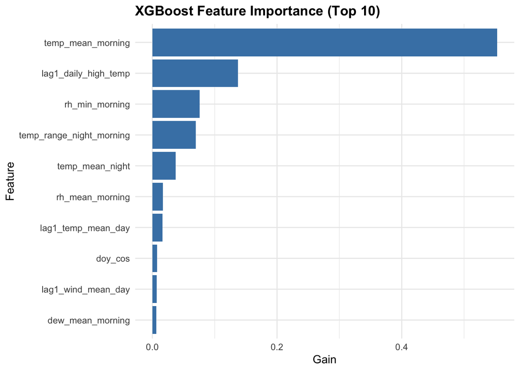

Figure 11: Top 10 features ranked by gain.

```r
# =========================================================
# Model Feature Importance Plot
# =========================================================

feature_importance_plot <- ggplot(
  importance_tbl,
  aes(x = reorder(Feature, Gain), y = Gain)
) +
  geom_col(fill = "steelblue") +
  coord_flip() +
  theme_capstone +
  labs(
    title = "XGBoost Feature Importance (Top 10)",
    x = "Feature",
    y = "Gain"
  )

feature_importance_plot
save_plot(feature_importance_plot, "feature_importance_top10.png")
```

**Interpretation:**

- **Morning Mean Temperature:** The morning mean temperature (`temp_mean_morning`) has the highest gain at 0.553, indicating that early‑day, morning, 6-11 UTC, temperatures are the primary driver of accurate daily high temperature forecasts at KLAX.
- **Temporal Persistence:** The importance of previous day’s high (`lag1_daily_high_temp`) and the previous day’s mean temperature (`lag1_temp_mean_day`) shows that yesterday’s temperature is persistent into today, which the model leverages.
- **Humidity‑Related Variables:** The minimum morning relative humidity (`rh_min_morning`), mean morning relative humidity (`rh_mean_morning`), and mean morning dewpoint (`dew_mean_morning`) all contribute meaningfully to the model, suggesting that moisture conditions play a notable role in the day’s maximum temperature.
- **Night‑to‑Morning Ranges:** The mean night temperature (`temp_mean_night`) and the temperature change between the mean of the morning and the mean of night (`temp_range_night_morning`) capture how the night time cooling and subsequent morning warming can effect the day’s temperatures, contributing additional explanatory power.
- **Seasonal and Wind Driven Signals:** The transformed version of the calendar day (`doy_cos`) helps capture the seasonal cycle and helps the model understand how typical temperatures change throughout the year. The mean wind speed from the previous day (`lag1_wind_mean_day`) allows the model to account for recent wind conditions that can carry warmer or cooler air into the area and influence today’s temperature.

When viewed together, these important features provide consistent insight into how KLAX warms over the course of a day. Morning temperature and humidity conditions, along with the previous day’s maximum temperature and average temperature, indicate that persistence and the diurnal cycle primarily drive the model’s forecast. The diurnal cycle’s role in this can be viewed as yesterday’s warmth sets the baseline with overnight cooling modifies it, and morning conditions reveal how quickly the atmosphere is poised to heat up. The presence of dewpoint and relative humidity in the 10 most influential features underscores the role of moisture and the marine layer in governing daytime highs, while wind‑related features reflect the importance of recent flow patterns in advecting cooler or warmer air into the region. Seasonal signals are also represented through the day-of-year transformation providing the model with a broader climatological backdrop that aides the model in understanding whether a given morning is unusually hot or cold for that time of year. Overall, these features show that the model is integrating a physically intuitive combination of persistence, diurnal cycle, moisture, wind, and seasonality to explain how daily high temperatures behave at KLAX.

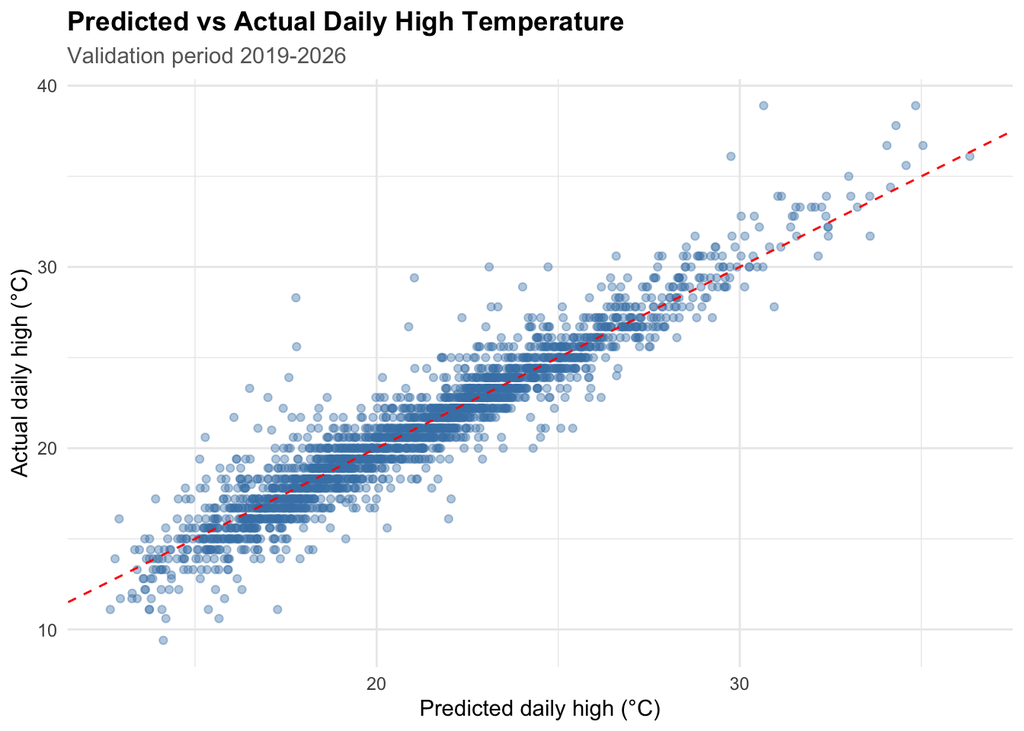

Figure 12

```r
# =========================================================
# Validation Diagnostics Data
# =========================================================

valid_diag <- valid_data %>%
  mutate(
    actual_high = as.numeric(y_valid),
    pred_high   = as.numeric(pred_valid),
    residual    = actual_high - pred_high
  )

# =========================================================
# Predicted vs Actual Daily Highs
# =========================================================

plot_pred_vs_actual <- ggplot(valid_diag, aes(x = pred_high, y = actual_high)) +
  geom_point(alpha = 0.4, color = "steelblue") +
  geom_abline(intercept = 0, slope = 1, color = "red", linetype = "dashed") +
  labs(
    title    = "Predicted vs Actual Daily High Temperature",
    subtitle = "Validation period 2019-2026",
    x        = "Predicted daily high (°C)",
    y        = "Actual daily high (°C)"
  ) +
  theme_capstone

plot_pred_vs_actual
save_plot(plot_pred_vs_actual, "plot_pred_vs_actual.png")
```

Figure 12 provides a visual comparison of the predicted versus the actual daily high temperatures from 2019-2026. The dashed line represents a perfect model with exact predictions. Overall, the points are closely aligned with the dashed line visually supports the $R^2$ of 0.904 previously discussed. Most points appear to be clustered in mid-range temperatures, with a decently tight spread. In the more extreme higher and lower range temperatures, there appears to be a wider spread, indicating that both unusually hot and cold days are more difficult to predict.

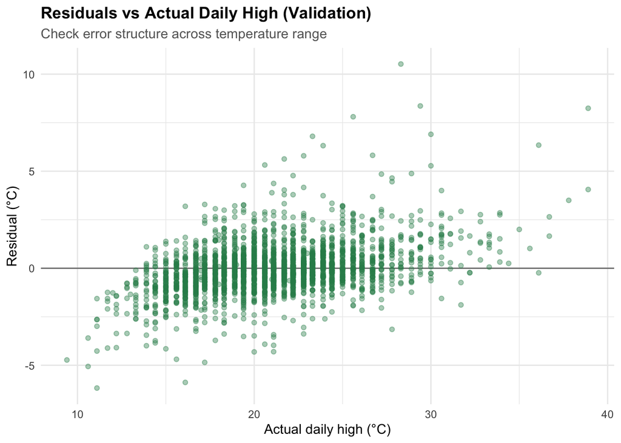

Figure 13

```r
# =========================================================
# Residuals vs Actual Temperature
# =========================================================

plot_resid_vs_actual <- ggplot(valid_diag, aes(x = actual_high, y = residual)) +
  geom_hline(yintercept = 0, color = "grey50") +
  geom_point(alpha = 0.4, color = "seagreen") +
  labs(
    title    = "Residuals vs Actual Daily High (Validation)",
    subtitle = "Check error structure across temperature range",
    x        = "Actual daily high (°C)",
    y        = "Residual (°C)"
  ) +
  theme_capstone

plot_resid_vs_actual
save_plot(plot_resid_vs_actual, "plot_resid_vs_actual.png")
```

Figure 13 shows residuals, prediction error in °C, against the observed daily high temperature on the validation set, allowing you to check whether errors depend on the actual daily high temperature. From roughly 15 °C to 30 °C, the residuals are centered close to zero with a fairly symmetric spread. Much like Figure 12, at the more extreme temperatures, the spread widens confirming that unusually hot and cold days are more difficult to predict.

### Conclusion

In this study, we demonstrated that daily high temperatures at KLAX can be predicted with high accuracy using an XGBoost regression model trained on features derived from the 5-minute ASOS observations. The model achieves small errors typically under a degree celsius and explains most of the day-to-day variance in daily high temperature. This indicates that the chosen preprocessing, feature engineering, and modeling strategy successfully capture the dominant signals that regulate the local temperatures. Morning conditions, the previous day’s high temperature, humidity, and wind‑related features together form a clear picture of how persistence, overnight cooling, and the state of the lower atmosphere relate to the eventual daily high.

However, an important limitation, the behavior of the model at temperature extremes, points to a potential direction for future research. While performance is strong for typical days, unusually hot and cold days are more difficult to predict. This suggests that these days may depend on factors not available in the local ASOS data, such as regional circulation patterns or large‑scale pressure systems. Overall, the methods developed in this study demonstrate a scalable framework for using high-resolution, high‑frequency meteorological data in forecasting, and they provide a foundation for further exploration of how machine learning can complement traditional weather prediction for both typical and extreme events.

## References

Airlangga, Gregorius. 2025. “Comparative Study of Machine Learning Models for Temperature Prediction: Analyzing Accuracy, Stability, and Generalization.” *Building of Informatics, Technology and Science (BITS)* 6 (4): 2672–80. https://doi.org/10.47065/bits.v6i4.7114.

Chen, Tianqi, and Carlos Guestrin. 2016. “XGBoost: A Scalable Tree Boosting System.” *Proceedings of the 22nd ACM SIGKDD International Conference on Knowledge Discovery and Data Mining*, KDD ’16, August, 785–94. https://doi.org/10.1145/2939672.2939785.

Dias, Daniela F., Daniel R. Cayan, and Alexander Gershunov. 2018. *Statistical Prediction of Minimum and Maximum Air Temperature in California and Western North America*. CCCA4-CEC-2018-011. California Energy Commission. https://www.energy.ca.gov/sites/default/files/2019-11/Projections_CCCA4-CEC-2018-011_ADA.pdf.

Dong, Jianhua, Wenzhi Zeng, Lifeng Wu, Jiesheng Huang, Thomas Gaiser, and Amit Kumar Srivastava. 2023. “Enhancing Short-Term Forecasting of Daily Precipitation Using Numerical Weather Prediction Bias Correcting with XGBoost in Different Regions of China.” *Engineering Applications of Artificial Intelligence* 117: 105579. https://doi.org/https://doi.org/10.1016/j.engappai.2022.105579.

Environmental Information (NCEI), NOAA National Center for. 2026. *Automated Surface Observing System (ASOS) Five-Minute Data*. https://www.ncei.noaa.gov/data/automated-surface-observing-system-five-minute/access/.

Khan, S. S., and R. Al-Hajj. 2025. “Multi-Output Deep Learning for High-Frequency Prediction of Air and Surface Temperature in Kuwait.” *Scientific Reports* 15 (39027): 39027. https://doi.org/10.1038/s41598-025-23455-4.

Singh, Deepnita, and Nisha Rawat. 2023. “Machine Learning for Weather Forecasting: XGBoost Vs SVM Vs Random Forest in Predicting Temperature for Visakhapatnam.” *International Journal of Intelligent Systems and Applications*. https://api.semanticscholar.org/CorpusID:262993809.

Wang, Han, Jiachuan Yang, Guangzhao Chen, Chao Ren, and Jize Zhang. 2023. “Machine Learning Applications on Air Temperature Prediction in the Urban Canopy Layer: A Critical Review of 2011–2022.” *Urban Climate* 49: 101499. https://doi.org/https://doi.org/10.1016/j.uclim.2023.101499.

Wiens, Matthew, Alissa Verone-Boyle, Nick Henscheid, Jagdeep T. Podichetty, and Jackson Burton. 2025. “A Tutorial and Use Case Example of the eXtreme Gradient Boosting (XGBoost) Artificial Intelligence Algorithm for Drug Development Applications.” *Clinical and Translational Science* 18 (3): e70172. https://doi.org/https://doi.org/10.1111/cts.70172.

Zhou, Xiang. 2023. “Comparison of Average Temperature Prediction Based on XGBoost and Prophet Models.” *Highlights in Science, Engineering and Technology* 76: 572–78. https://doi.org/10.54097/x2s0s641.